# Calculus I

NU Social Science Math Camp

## What have we learned so far?

Foundational ideas behind what you will have to deal with during your graduate program:

- Reading about methods $\rightarrow$ Notation, sets, functions
- Working with *data frames* $\rightarrow$ Matrix operations

## Up next

Dealing with **continuity** (which implies *infinity*) $\rightarrow$ Calculus

Two new operators:

1. Derivatives **(Today)**
2. Integrals **(Friday)**

## Calculus

- This is often where people experience the most difficulty
- We are now operating with whole functions!
- New operators have new, different rules
- We will stick together!

## Derivatives as a slope

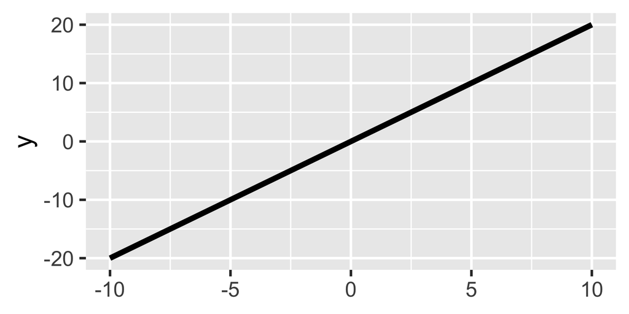

- How do we find the slope of this line?
- $m = \frac{f(x_2) - f(x_1)}{x_2-x_1} = \frac{rise}{run}$
- Let’s try it out!

## Now try this one!

$y = x^2$

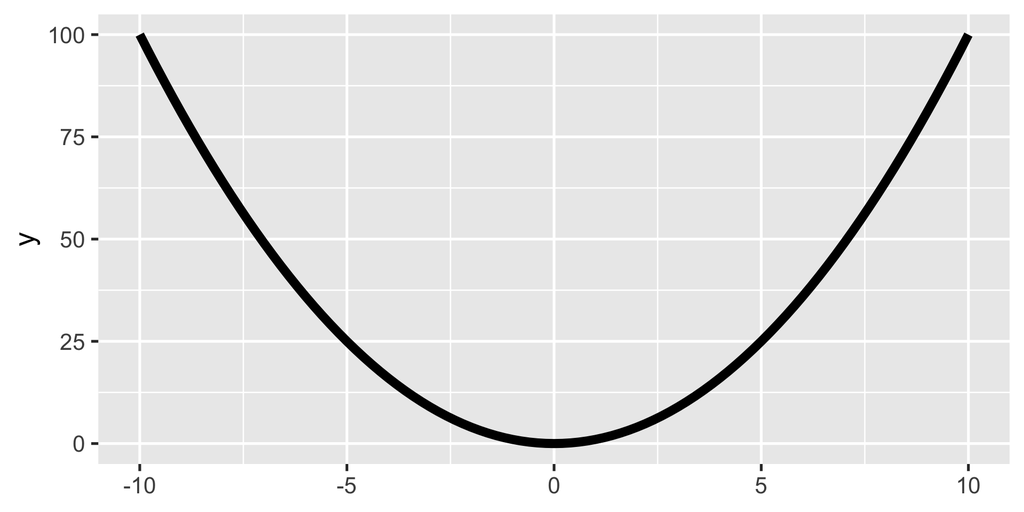

## Why doesn’t it work?

- We need an operation to calculate the slope or *rate of change* for (almost) any kind of *continuous* function
- Enter **derivatives**

Generalize slope formula

$$m = \frac{f(x_1+ \Delta x) - f(x_1)}{\Delta x}$$

## Derivatives

When $\Delta x$ is small enough

$$\lim_{\Delta x\to0} \frac{f(x_1+ \Delta x) - f(x_1)}{\Delta x} = \frac{d}{dx} f(x) = \frac{dy}{dx} = f'(x)$$

- Read $\frac{d}{dx} f(x)$ as “the derivative of $f$ of $x$ with respect to $x$”
- Read $f'(x)$ as “$f$ prime $x$” for a shorthand

## How to compute?

- Can try to plug in many values
- Use properties of limits
- Use Software

## Rules of differentiation

**Differentation:** “Taking the derivative”

## Rules of differentiation

**Constant rule:** $(c)' = 0$.

$y = 2$

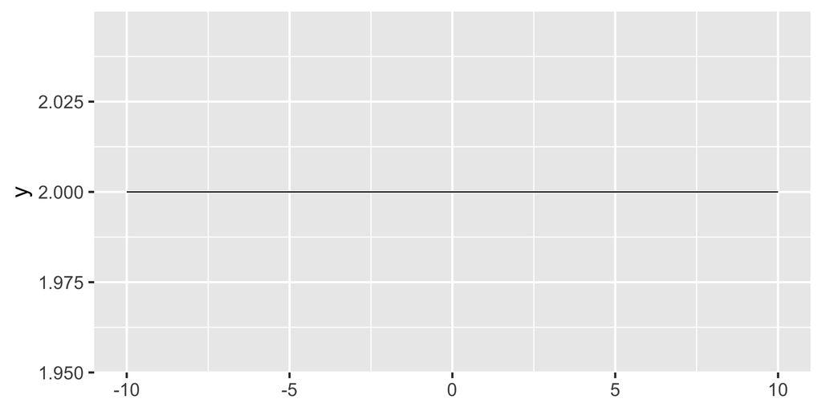

## Rules of differentiation

**Coefficient rule:** $(c \cdot f(x))' = c \cdot f'(x)$

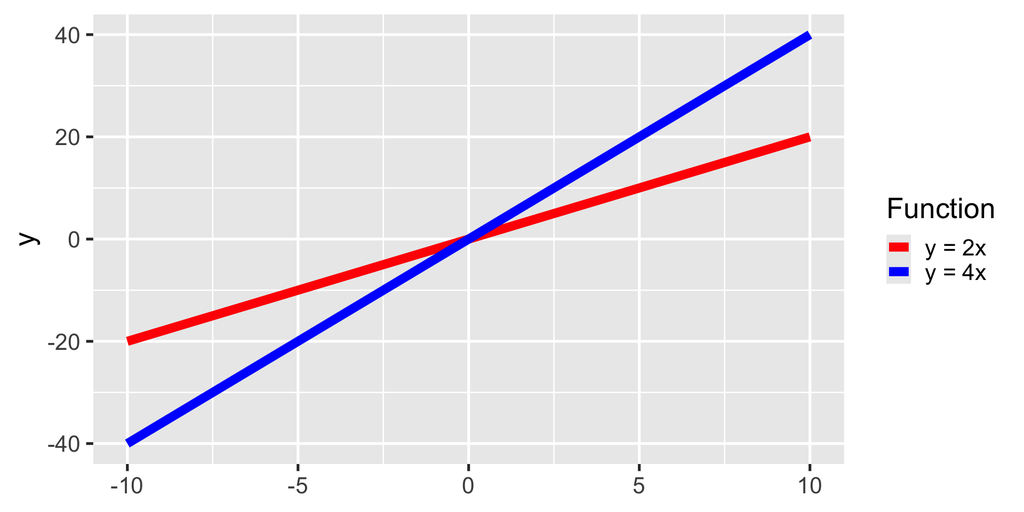